# ME - GIA. Count data (Models)

15 oct. 2024

# Introduction

## Example. Scientific articles

The PhD Mentoring and Productivity Dataset originates from the study titled “Do Teachers’ and Students’ Characteristics Affect Productivity? The Role of Mentoring” by Ronald G. Ehrenberg, Daniel D. Goldhaber, and Dominic J. Brewer (1995). The dataset explores the factors influencing the academic productivity of Ph.D. students, specifically in the context of the number of articles they publish during the final three years of their doctoral studies.

The key variables in the dataset include:

**Outcome**

- **art**: articles in last three years of PhD

**Explanatory variables**

- **fem**: coded one for females
- **mar**: coded one if married
- **kid5**: number of children under age six
- **phd**: prestige of Ph.D. program
- **ment**: articles by mentor in last three years

# Descriptive analysis

## Univariate exploratory data analysis

```r
summary(ab)
```

```
##       art            fem           mar           kid5             phd
##  Min.   : 0.000   Men  :494   Single :309   Min.   :0.0000   Min.   :0.755
##  1st Qu.: 0.000   Women:421   Married:606   1st Qu.:0.0000   1st Qu.:2.260
##  Median : 1.000                             Median :0.0000   Median :3.150
##  Mean   : 1.693                             Mean   :0.4951   Mean   :3.103
##  3rd Qu.: 2.000                             3rd Qu.:1.0000   3rd Qu.:3.920
##  Max.   :19.000                             Max.   :3.0000   Max.   :4.620
##       ment
##  Min.   : 0.000
##  1st Qu.: 3.000
##  Median : 6.000
##  Mean   : 8.767
##  3rd Qu.:12.000
##  Max.   :77.000
```

## Bivariate descriptive analysis

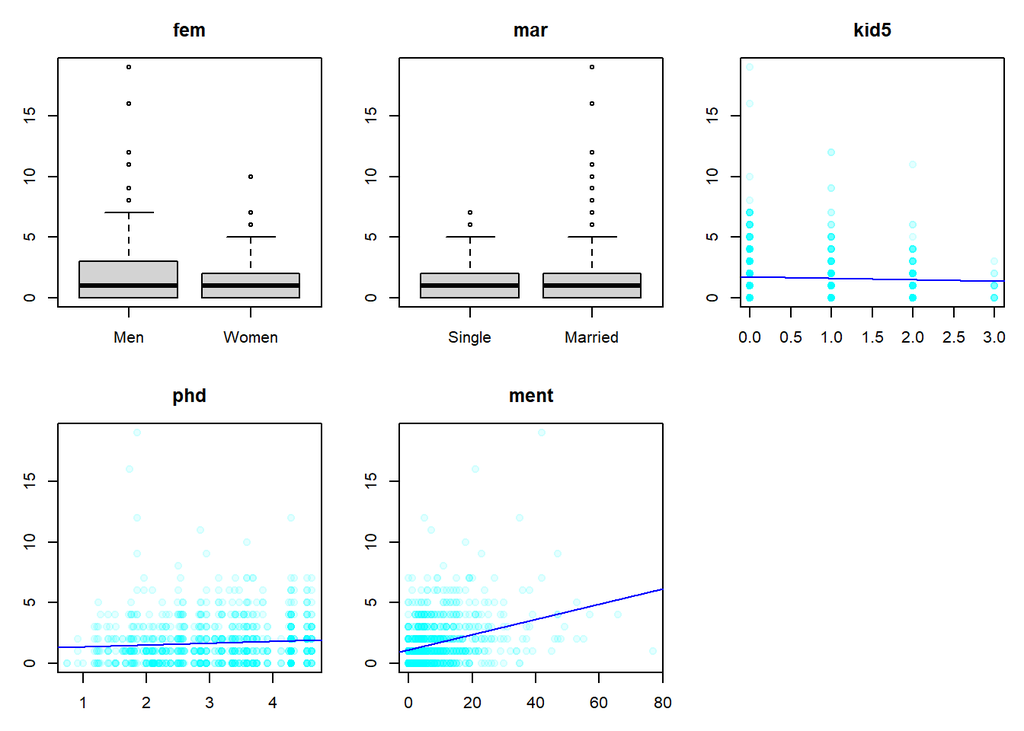

```r
vars <- colnames(ab)[-1] # all variables except outcome: -21

par(mfrow=c(2,3), mar=c(3,3,3,1)) # 4x5 windows with margins 3,3,3,1

# Plot if numeric and boxplot if categorical
for (v in vars){
  form <- as.formula(paste0("art~",v))
  if (!is.factor(ab[,v])){
    plot(form, data = ab, main = v, pch=19,col=rgb(0,1,1,0.1))
    abline(lm(form,data = ab), col='blue')
  }else{
    boxplot(form, data = ab, main = v)
  }
}
```

# Models

## Poisson model

```r
mp <- glm(art ~ fem + mar + kid5 + phd + ment, family=poisson, data=ab)
summary(mp)
```

```
##
## Call:
## glm(formula = art ~ fem + mar + kid5 + phd + ment, family = poisson,
##     data = ab)
##
## Coefficients:
##              Estimate Std. Error z value Pr(>|z|)
## (Intercept)  0.304617   0.102981   2.958   0.0031 **
## femWomen    -0.224594   0.054613  -4.112 3.92e-05 ***
## marMarried   0.155243   0.061374   2.529   0.0114 *
## kid5        -0.184883   0.040127  -4.607 4.08e-06 ***
## phd          0.012823   0.026397   0.486   0.6271
## ment         0.025543   0.002006  12.733  < 2e-16 ***
## ---
## Signif. codes:  0 '***' 0.001 '**' 0.01 '*' 0.05 '.' 0.1 ' ' 1
##
## (Dispersion parameter for poisson family taken to be 1)
##
##     Null deviance: 1817.4  on 914  degrees of freedom
## Residual deviance: 1634.4  on 909  degrees of freedom
## AIC: 3314.1
##
## Number of Fisher Scoring iterations: 5
```

### Validation

**Numeric validation**

```r
qchisq(0.95, df.residual(mp))
```

```
## [1] 980.2518
```

**Graphical validation**

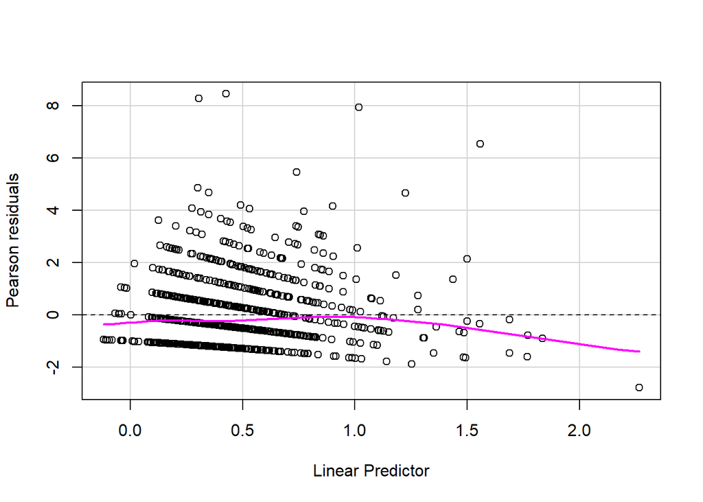

```r
residualPlot(mp)
```

### Overdispersion

**Pearson statistic**

Person statistic divided by the degrees of freedom should be close to one.

```r
phi <- sum(residuals(mp, type = 'pearson')^2)/mp$df.residual
```

**Formal test**

```r
dispersiontest(mp, trafo=1) # quasi-poisson  --> V = (1 + alpha) * mu = phi * mu
```

```
##
##  Overdispersion test
##
## data:  mp
## z = 5.7825, p-value = 3.681e-09
## alternative hypothesis: true alpha is greater than 0
## sample estimates:
##     alpha
## 0.8245398
```

```r
dispersiontest(mp, trafo=2) # negative binom --> V = mu + alpha * mu^2 = mu + 1/theta * mu^2
```

```
##
##  Overdispersion test
##
## data:  mp
## z = 6.5297, p-value = 3.295e-11
## alternative hypothesis: true alpha is greater than 0
## sample estimates:
##     alpha
## 0.5091216
```

There is overdispersion that should be corrected. Both tests to check whether the variance depends linearly on the expectation (*trafo=1*) and to see if it depends quadratically (*trafo=2*) are significant: - `trafo = 1` $\rightarrow V[Y_i|X_i] = (1+0.82) \cdot E[Y_i|X_i]$ - `trafo = 2` $\rightarrow V[Y_i|X_i] = E[Y_i|X_i] + 0.51 \cdot E[Y_i|X_i]^2$

## Quasi-Poisson model

```r
summary(mq <- glm(art ~ fem + mar + kid5 + phd + ment,
                  family=quasipoisson, data=ab))
```

```
##
## Call:
## glm(formula = art ~ fem + mar + kid5 + phd + ment, family = quasipoisson,
##     data = ab)
##
## Coefficients:
##              Estimate Std. Error t value Pr(>|t|)
## (Intercept)  0.304617   0.139273   2.187 0.028983 *
## femWomen    -0.224594   0.073860  -3.041 0.002427 **
## marMarried   0.155243   0.083003   1.870 0.061759 .
## kid5        -0.184883   0.054268  -3.407 0.000686 ***
## phd          0.012823   0.035700   0.359 0.719544
## ment         0.025543   0.002713   9.415  < 2e-16 ***
## ---
## Signif. codes:  0 '***' 0.001 '**' 0.01 '*' 0.05 '.' 0.1 ' ' 1
##
## (Dispersion parameter for quasipoisson family taken to be 1.829006)
##
##     Null deviance: 1817.4  on 914  degrees of freedom
## Residual deviance: 1634.4  on 909  degrees of freedom
## AIC: NA
##
## Number of Fisher Scoring iterations: 5
```

The AIC cannot be calculated because there is no complete probabilistic model. The quasi-poisson model uses the estimate by the Pearson statistic to correct the standard errors inflating them by **1.35** ($\hat{\phi}=\sqrt{1.82}$).

## Quasi-Poisson vs. Poisson

We can compare both models

```r
se <- function(model) sqrt(diag(vcov(model)))
kable(round(data.frame(coef_pois = coef(mp),  coef_quasi = coef(mq), # Coefficients
                       se_pois   = se(mp),    se_quasi   = se(mq),   # Standard errors
                       se_ratio  = se(mq)/se(mp)),                   # SE Ratio
            4))
```

|  | coef_pois | coef_quasi | se_pois | se_quasi | se_ratio |
| --- | --- | --- | --- | --- | --- |
| (Intercept) | 0.3046 | 0.3046 | 0.1030 | 0.1393 | 1.3524 |
| femWomen | -0.2246 | -0.2246 | 0.0546 | 0.0739 | 1.3524 |
| marMarried | 0.1552 | 0.1552 | 0.0614 | 0.0830 | 1.3524 |
| kid5 | -0.1849 | -0.1849 | 0.0401 | 0.0543 | 1.3524 |
| phd | 0.0128 | 0.0128 | 0.0264 | 0.0357 | 1.3524 |
| ment | 0.0255 | 0.0255 | 0.0020 | 0.0027 | 1.3524 |

The coefficients of the Poisson and Quasi-Poisson models are the same and the standard errors are multiplied by 1.35 which is obtained from the square root of the Pearson statistic divided by its degrees of freedom.

## Negative Binomial

```r
summary(mnb <- glm.nb(art ~ fem + mar + kid5 + phd + ment, data=ab))
```

```
##
## Call:
## glm.nb(formula = art ~ fem + mar + kid5 + phd + ment, data = ab,
##     init.theta = 2.264387695, link = log)
##
## Coefficients:
##              Estimate Std. Error z value Pr(>|z|)
## (Intercept)  0.256144   0.137348   1.865 0.062191 .
## femWomen    -0.216418   0.072636  -2.979 0.002887 **
## marMarried   0.150489   0.082097   1.833 0.066791 .
## kid5        -0.176415   0.052813  -3.340 0.000837 ***
## phd          0.015271   0.035873   0.426 0.670326
## ment         0.029082   0.003214   9.048  < 2e-16 ***
## ---
## Signif. codes:  0 '***' 0.001 '**' 0.01 '*' 0.05 '.' 0.1 ' ' 1
##
## (Dispersion parameter for Negative Binomial(2.2644) family taken to be 1)
##
##     Null deviance: 1109.0  on 914  degrees of freedom
## Residual deviance: 1004.3  on 909  degrees of freedom
## AIC: 3135.9
##
## Number of Fisher Scoring iterations: 1
##
##
##               Theta:  2.264
##           Std. Err.:  0.271
##
##  2 x log-likelihood:  -3121.917
```

Estimate of $\theta$ and use in `glm`:

```r
1/mnb$theta
```

```
## [1] 0.4416205
```

```r
summary(mnbg <- glm(art ~ fem + mar + kid5 + phd + ment,
                    family = negative.binomial(mnb$theta), data=ab))
```

```
##
## Call:
## glm(formula = art ~ fem + mar + kid5 + phd + ment, family = negative.binomial(mnb$theta),
##     data = ab)
##
## Coefficients:
##              Estimate Std. Error t value Pr(>|t|)
## (Intercept)  0.256149   0.140008   1.830  0.06765 .
## femWomen    -0.216420   0.074043  -2.923  0.00355 **
## marMarried   0.150490   0.083686   1.798  0.07247 .
## kid5        -0.176416   0.053836  -3.277  0.00109 **
## phd          0.015271   0.036568   0.418  0.67633
## ment         0.029082   0.003277   8.876  < 2e-16 ***
## ---
## Signif. codes:  0 '***' 0.001 '**' 0.01 '*' 0.05 '.' 0.1 ' ' 1
##
## (Dispersion parameter for Negative Binomial(2.2644) family taken to be 1.03911)
##
##     Null deviance: 1109.0  on 914  degrees of freedom
## Residual deviance: 1004.3  on 909  degrees of freedom
## AIC: 3133.9
##
## Number of Fisher Scoring iterations: 6
```

### Validation

```r
deviance(mnbg)
```

```
## [1] 1004.281
```

```r
qchisq(0.95,909)
```

```
## [1] 980.2518
```

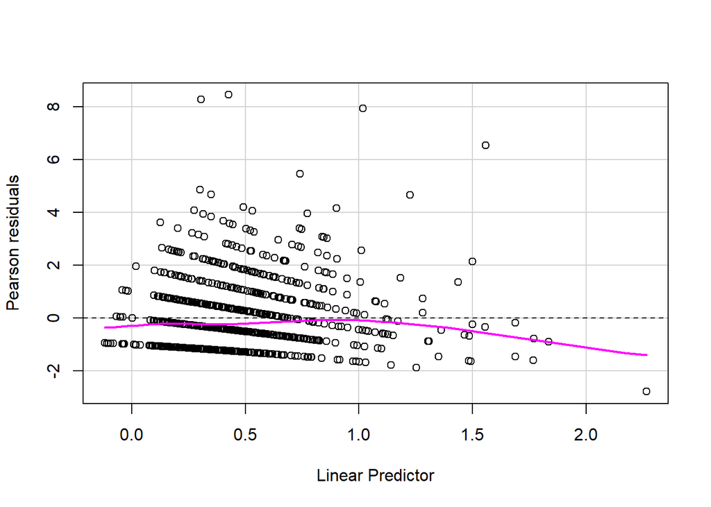

```r
residualPlot(mq)
```

- The model does not fit the data well since the residual deviance is in the non-acceptance region of $H_0$
- The estimate of $\theta$ provided by the model ($2.26$) is similar to that provided by *dispersion.test* ($1.96 = 1/0.509$).

## Zero-inflated poisson

In the zero-inflated Poisson model, we have 2 models in one:

- A logit model (lower output of `zeroinfl`) to predict the probability of belonging to the structural zero class.
- A Poisson model (upper output of `zeroinfl`) for the random zeros and the rest of the values.

```r
summary(mzip <- zeroinfl(art ~ fem + mar + kid5 + phd + ment, data=ab))
```

```
##
## Call:
## zeroinfl(formula = art ~ fem + mar + kid5 + phd + ment, data = ab)
##
## Pearson residuals:
##     Min      1Q  Median      3Q     Max
## -2.3253 -0.8652 -0.2826  0.5404  7.2976
##
## Count model coefficients (poisson with log link):
##              Estimate Std. Error z value Pr(>|z|)
## (Intercept)  0.640838   0.121307   5.283 1.27e-07 ***
## femWomen    -0.209145   0.063405  -3.299 0.000972 ***
## marMarried   0.103751   0.071111   1.459 0.144565
## kid5        -0.143320   0.047429  -3.022 0.002513 **
## phd         -0.006166   0.031008  -0.199 0.842378
## ment         0.018098   0.002294   7.888 3.07e-15 ***
##
## Zero-inflation model coefficients (binomial with logit link):
##              Estimate Std. Error z value Pr(>|z|)
## (Intercept) -0.577059   0.509386  -1.133  0.25728
## femWomen     0.109746   0.280082   0.392  0.69518
## marMarried  -0.354014   0.317611  -1.115  0.26502
## kid5         0.217097   0.196482   1.105  0.26919
## phd          0.001274   0.145263   0.009  0.99300
## ment        -0.134114   0.045243  -2.964  0.00303 **
## ---
## Signif. codes:  0 '***' 0.001 '**' 0.01 '*' 0.05 '.' 0.1 ' ' 1
##
## Number of iterations in BFGS optimization: 21
## Log-likelihood: -1605 on 12 Df
```

### Validation

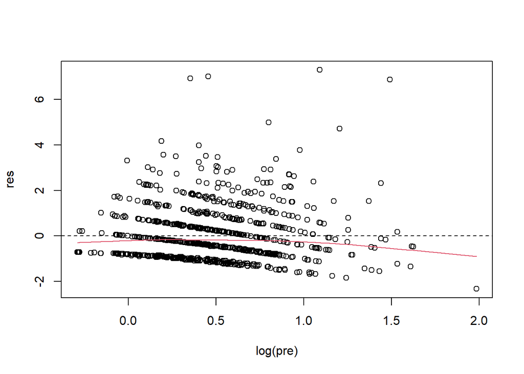

```r
## Residuals versus predicted
res <- residuals(mzip, type = 'pearson')  # Residuals
pre <- predict(  mzip, type = 'response') # Predicted
plot(res~log(pre))
abline(h = 0,lty = 2)
lines(lowess(log(pre),res), col=2)
```

### Exercise

1. What is the probability of structural zero for a **single woman** with **no children under 6 years** in a program with **prestige=3** and **1 published article** by her mentor?

```r
# With function
pr_func <- predict(mzip,
                   newdata = data.frame(fem='Women',mar='Single',kid5=0,phd=3,ment=1),
                   type    = 'zero')

# By hand
co      <- coef(mzip)
pl      <-     co['zero_(Intercept)']  +
               co['zero_femWomen']  +
           3 * co['zero_phd'] +
           1 * co['zero_ment']
pr_hand <- exp(pl)/(1 + exp(pl))
round(as.numeric(c(pr_func,pr_hand)),3)
```

```
## [1] 0.355 0.355
```

2. What is the expected mean for this woman?

```r
# With function
mu_func <- predict(mzip,
                   newdata = data.frame(fem='Women',mar='Single',kid5=0,phd=3,ment=1),
                   type    = 'response')

# By hand
pl0     <-     co['count_(Intercept)'] +
               co['count_femWomen']    +
           3 * co['count_phd']         +
           1 * co['count_ment']

mu2_0   <- exp(pl0)
mu_hand <- (1 - pr_hand) * mu2_0
round(as.numeric(c(mu_func, mu_hand)),3)
```

```
## [1] 0.993 0.993
```

3. How much more likely is a woman to be a structural zero than a man?

```r
round(as.numeric(exp(co['zero_femWomen'])),3)   # Odds ratio
```

```
## [1] 1.116
```